# OncoMarker: Targeted Genomic Analysis Workflow

Premitha Pagadala

2025-11-27

# 1. Introduction

The OncoMarker package provides a streamlined S4 object-oriented framework for analyzing targeted genomic panels. It is designed to bridge the gap between massive public datasets (like TCGA) and clinical biomarker discovery.

This vignette demonstrates the end-to-end workflow:  
1. Ingesting raw text data (Level 3 expression).  
2. Constructing the strictly typed GenePanel S4 object.  
3. Performing differential expression analysis.  
4. Visualizing results via Volcano plots.  
5. Stratifying patients based on risk biomarkers.

# 2. Data Ingestion & Object Construction

The OncoMarker framework relies on the GenePanel class to ensure data integrity. The code below demonstrates how to load raw text files and create the object.

Note: The code below assumes you have the specific TCGA text files locally.

```r
# 1. Define Paths to your raw data
normal_path <- "../raw_data/BC-TCGA-Normal.txt"
tumor_path  <- "../raw_data/BC-TCGA-Tumor.txt"

# 2. Load Data
# We use read.delim to strictly handle tab-separation and avoid parsing errors
normal_df <- read.delim(normal_path, header=TRUE, row.names=1, check.names=FALSE)
tumor_df  <- read.delim(tumor_path, header=TRUE, row.names=1, check.names=FALSE)

# 3. ETL: Merge and Format
# Bind columns: Normal samples first, then Tumor samples
expr_mat <- as.matrix(cbind(normal_df, tumor_df))

# CRITICAL STEP: Ensure matrix is numeric (converts text to numbers)
storage.mode(expr_mat) <- "numeric"

# 4. Create Clinical Metadata
# We automatically generate labels based on the column counts
meta_df <- data.frame(
  SampleID = colnames(expr_mat),
  Diagnosis = factor(c(rep("Normal", ncol(normal_df)), rep("Tumor", ncol(tumor_df)))),
  row.names = colnames(expr_mat)
)

# 5. Create the S4 Object
# This step runs internal validation to ensure dimensions match
panel <- new("GenePanel",
             expression_data = expr_mat,
             patient_metadata = meta_df,
             cancer_type = "TCGA-BRCA")

show(panel)
```

[output not shown]

[output cut: 1045 more lines]

[output not shown]

# 3. Differential Expression Analysis

Once the GenePanel object is created, we can identify significant drivers using the calc_fold_change method. This utilizes Welch’s t-test to handle unequal variances between tumor and normal tissues.

```r
# Calculate Log2 Fold Change and P-values
results <- calc_fold_change(panel)
```

```
#> [1] "Analyzing 17814 genes across 590 samples..."
```

```r
# Display the top significant genes
head(results)
```

|  | Gene | Log2FC | PValue | FDR |
| --- | --- | --- | --- | --- |
| 17524 | ITM2A | -2.981790 | 1.012652e-86 | 1.803939e-82 |
| 11097 | SFRP1 | -4.581451 | 5.653358e-78 | 5.035446e-74 |
| 17396 | OSR1 | -2.739629 | 7.619958e-77 | 4.524731e-73 |
| 8666 | HOXA4 | -2.942836 | 7.145809e-75 | 3.182386e-71 |
| 12314 | UBE2E3 | -1.179885 | 3.253644e-71 | 1.159208e-67 |
| 8599 | CNTNAP3 | -2.470789 | 9.330959e-71 | 2.770362e-67 |

# 4. Visualization: The Volcano Plot

Visualizing genomic alterations is crucial for interpretation. The plot_volcano method automatically highlights significant upregulation (Red) and downregulation (Blue).

```r
# Generate plot
p <- plot_volcano(panel)
```

```
#> [1] "Analyzing 17814 genes across 590 samples..."
```

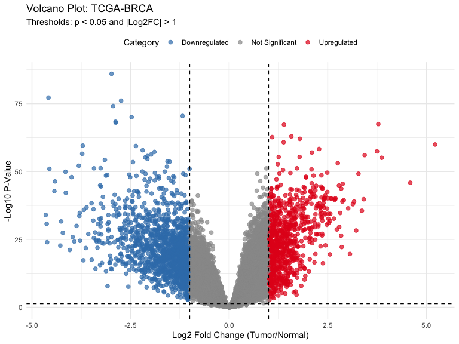

```r
# Display
print(p)
```

Volcano plot highlights: Red points: Significantly upregulated in tumors Blue points: Significantly downregulated Grey points: Not significant

# 5. Clinical Risk Stratification

Finally, we can move from descriptive analysis to prognostic modeling. The predict_risk function stratifies the cohort into “High Risk” and “Low Risk” groups based on the median expression of a specific biomarker.

Example: Stratifying by TP53 (Tumor Suppressor) Logic: Low expression indicates loss of function -> High Risk.

```r
# Predict risk based on TP53 levels
risk_scores <- predict_risk(panel, gene = "TP53", direction = "low_risk_high_expr")
```

```
#> [1] "Stratifying cohort based on TP53 median expression: -0.3"
```

```r
# View the distribution of patients
table(risk_scores)
```

```
#> risk_scores
#>  Low Risk High Risk
#>       295       295
```

# 6. Summary & Key Findings

## Risk Stratification Insights

Using the `predict_risk()` function, patients were categorized into High Risk and Low Risk groups. This allows immediate translation to survival analyses or clinical decision support workflows.

```r
# Summarize risk distribution
table(panel@patient_metadata$Risk)
```

[output not shown]

```
#> < table of extent 0 >
```

# 7. References & Further Reading

## Data Sources

1. Breast Cancer Gene Expression Profiles (TCGA) – Kaggle  
   [https://www.kaggle.com/datasets/orvile/gene-expression-profiles-of-breast-cancer](https://www.kaggle.com/datasets/orvile/gene-expression-profiles-of-breast-cancer?resource=download)

## R Programming & Tutorials

2. R Programming & Tutorials – R-Coder  
   https://r-coder.com/
3. Applied Modeling & Text Analysis – Julia Silge Blog  
   https://juliasilge.com/blog/
4. Visualization with ggplot2 – R Graph Gallery  
   https://r-graph-gallery.com/ggplot2-package.html
5. Comprehensive R Learning Libraries – Awesome R Resources  
   https://github.com/iamericfletcher/awesome-r-learning-resources?tab=readme-ov-file

## Suggested Reading for Clinical Genomics

6. The Cancer Genome Atlas (TCGA) – National Cancer Institute  
   https://www.cancer.gov/tcga
7. cBioPortal for Cancer Genomics  
   https://www.cbioportal.org
8. Bioinformatics Workflows and Differential Expression Analysis (Friedman et al., 2023)